# Genetic differentiation on flowering time in Cerastium fontanum using a greenhouse experiment

Data preparation and first analyses

Alicia Valdés

03 April, 2023

# Data preparation

## Read data from Excel files

```r
data_exp<-read_excel("data/edited/Cerastium_greenhouse_spring_2022_editedAV.xlsx",
                       sheet="extracted_data")
data_exp$treat<-as.factor(data_exp$treat)
data_exp$mother<-as.factor(data_exp$mother)
data_exp$father<-as.factor(data_exp$father)
data_exp$total_n_fl<-as.integer(data_exp$total_n_fl)
data_exp$date50<-as.numeric(data_exp$date50)
data_exp$unique_id<-as.factor(data_exp$unique_id)
data_exp<-data_exp%>%filter(unique_id!="122/144_41")
# Remove one case where temperature of the parents is not known
```

```r
data_selfed<-read_excel("data/edited/Cerastium_greenhouse_spring_2022_editedAV.xlsx",
                       sheet="extracted_data_parents")
data_selfed$treat<-as.factor(data_selfed$treat)
data_selfed$id_parent<-as.factor(data_selfed$id_parent)
```

```r
data_shoots<-read_excel("data/edited/Cerastium_greenhouse_spring_2022_editedAV.xlsx",
                       sheet="extracted_data_shoots")
data_shoots$unique_id<-as.factor(data_shoots$unique_id)
# Dates say 2022 and that is not true, but should be OK if we need to
# calculate differences
```

```r
head(data_exp)
```

| mother | father | temp_mother | temp_father | treat | total_n_fl | FFD | LFD | date50 | Comments | ID-last_name | ID-number_last | unique_id | mother_originalID_iceland | father_originalID_iceland |
| --- | --- | --- | --- | --- | --- | --- | --- | --- | --- | --- | --- | --- | --- | --- |
| 16 | 120 | 25.9 | 11.3 | unheated | 13 | 129 | 154 | 138 | NA | 162 | 2:3 | 162_23 | H05 422:3/2 | H04 404:3/3 |
| 39 | 350 | 22.6 | 20.6 | unheated | 0 | NA | NA | NA | NA | 395 | 2:2 | 395_22 | H13 811:1/1 | H04 99:3/3 |
| 26 | 250 | 21.5 | 23.4 | unheated | 6 | 124 | 140 | 129 | NA | 265 | 4:4 | 265_44 | H13 828:3/2 | H05 432:1/2 |
| 31 | 310 | 7.0 | 8.0 | unheated | 64 | 115 | 150 | 128 | NA | 311 | 2:1 | 311_21 | HC5 1149:3/3 | HC2a 878:1/3 |
| 24 | 210 | 14.9 | 7.0 | unheated | 6 | 124 | 145 | 129 | NA | 241 | 4:3 | 241_43 | H04 407:1/3 | HC1 834:1/2 |
| 34 | 320 | 18.0 | 9.0 | unheated | 15 | 129 | 161 | 138 | NA | 342 | 4:2 | 342_42 | H04 400:3/2 | H09 358:3/2 |

```r
head(data_selfed)
```

| id_parent | temp | treat | total_n_fl | FFD | LFD | date50 | Comments |
| --- | --- | --- | --- | --- | --- | --- | --- |
| 13 | 12.0 | unheated | 13 | 129 | 152 | 139 | NA |
| 13 | 12.0 | heatmat | 16 | 124 | 131 | 125 | NA |
| 13 | 12.0 | heatmat | 4 | 126 | 136 | 131 | NA |
| 14 | 29.8 | unheated | 2 | 133 | 136 | 133 | Both mother and father |
| 14 | 29.8 | heatmat | 1 | 138 | 138 | 137 | Both mother and father |
| 14 | 29.8 | heatmat | 2 | 131 | 136 | 131 | Both mother and father |

```r
head(data_shoots)
```

| ID-name | ID-number | unique_id | date1 | sh1_date1 | sh2_date1 | sh3_date1 | date2 | sh1_date2 | sh2_date2 | sh3_date2 | comments |
| --- | --- | --- | --- | --- | --- | --- | --- | --- | --- | --- | --- |
| 162 | 23 | 162_23 | 2022-04-04 | 15 | 7 | 11 | 2022-04-28 | 25 | 16 | 7 | NA |
| 395 | 22 | 395_22 | 2022-04-04 | 9 | 5 | 7 | 2022-04-28 | 7 | 23 | 14 | NA |
| 265 | 44 | 265_44 | 2022-04-04 | 12 | 10 | 8 | 2022-04-28 | 22 | 17 | 24 | NA |
| 311 | 21 | 311_21 | 2022-04-04 | 11 | 20 | 14 | 2022-04-28 | 18 | 16 | 18 | NA |
| 241 | 43 | 241_43 | 2022-04-04 | 6 | 7 | 7 | 2022-04-28 | 29 | 39 | 16 | NA |
| 342 | 42 | 342_42 | 2022-04-04 | 13 | 5 | 9 | 2022-04-28 | 25 | 27 | 35 | NA |

## Unique id is unique in all cases –> Fixed

```r
data_exp%>%group_by(unique_id)%>%summarise(count=n())%>%filter(count>1)
```

| unique_id | count |
| --- | --- |

```r
data_shoots%>%group_by(unique_id)%>%summarise(count=n())%>%filter(count>1)
```

| unique_id | count |
| --- | --- |

## How many different mothers and fathers?

```r
length(levels(data_exp$mother)) # 25 different mothers (shouldn't it be 24?)
```

```
## [1] 25
```

```r
length(levels(data_exp$father)) # 24 different mothers
```

```
## [1] 24
```

## How many unique combinations of mothers and fathers?

```r
data_exp<-data_exp%>%mutate(mother_father=paste(mother,father,sep="_"))
```

```r
length(unique(data_exp$mother_father)) # 99 (shouldn't it be 96?)
```

```
## [1] 99
```

## Number of plants from each crossing

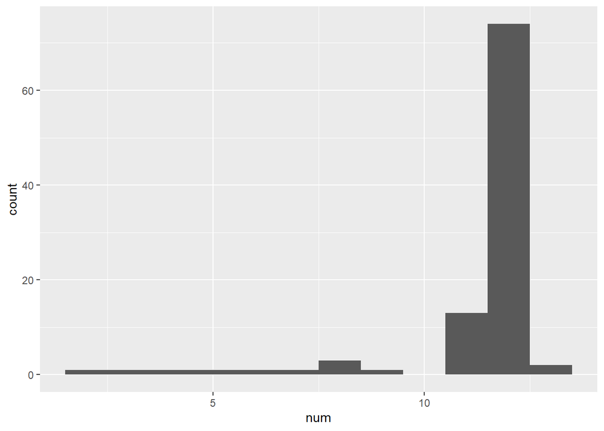

```r
data_exp%>%group_by(mother_father)%>%summarise(num=n())%>%
  ggplot(aes(x=num))+geom_histogram(bins=12)
```

# Distributions

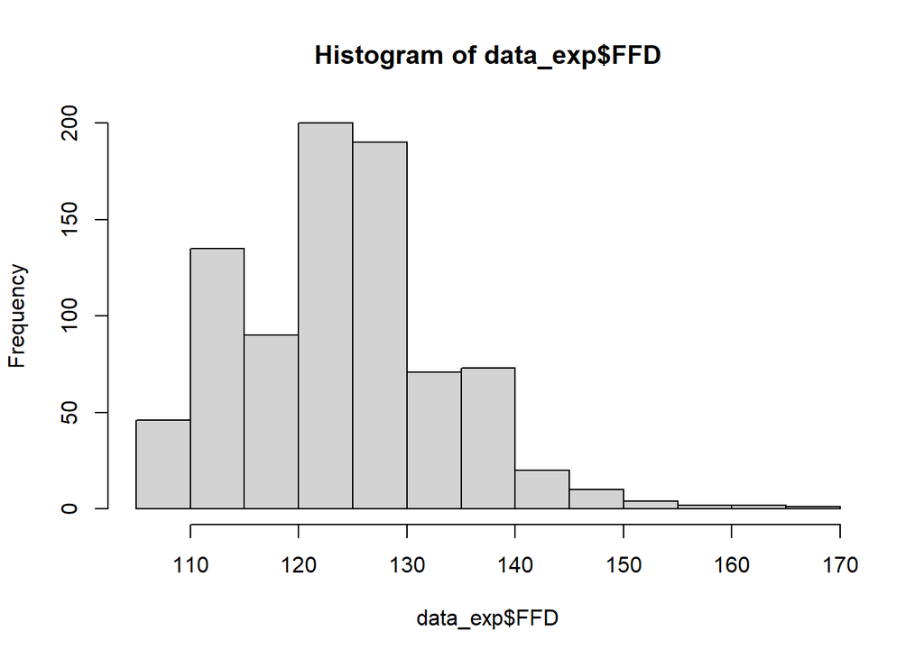

```r
hist(data_exp$FFD)
```

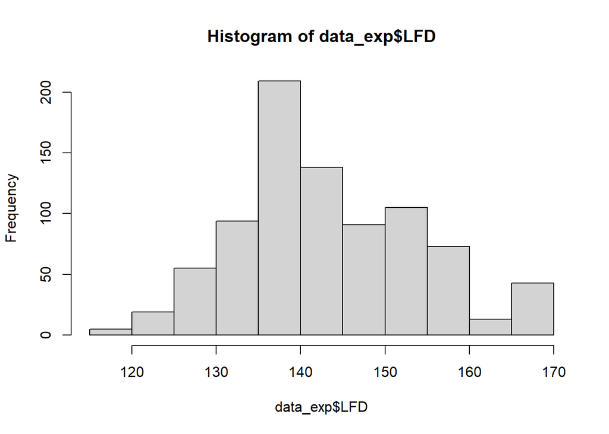

```r
hist(data_exp$LFD)
```

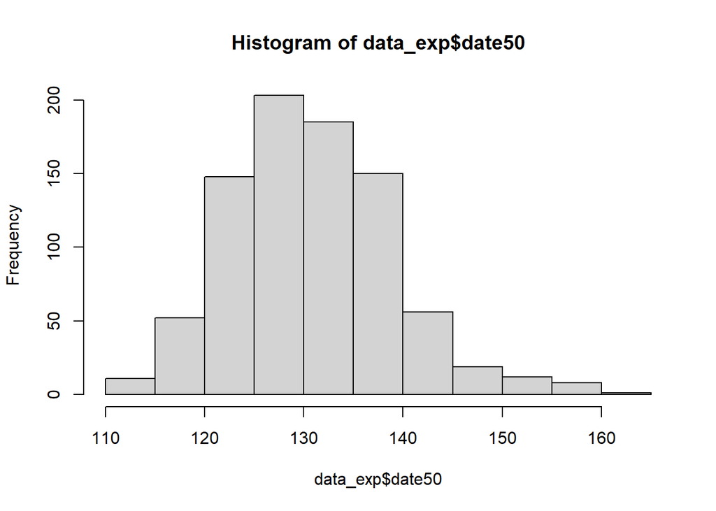

```r
hist(data_exp$date50)
```

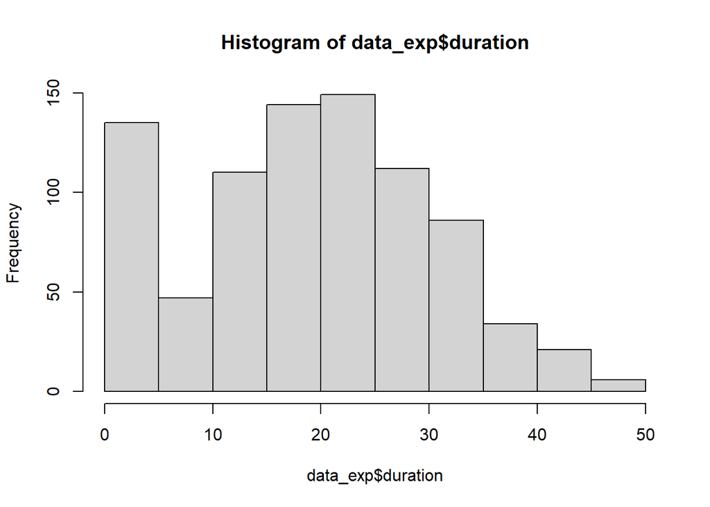

```r
data_exp$duration<-data_exp$LFD-data_exp$FFD
hist(data_exp$duration)
```

All looking quite normal.

# Shoots

```r
data_shoots<-data_shoots%>%mutate(day_diff=date2-date1,
                                  mean_sh_h_date1=(sh1_date1+sh2_date1+sh3_date1)/3,
                                  mean_sh_h_date2=(sh1_date2+sh2_date2+sh3_date2)/3,
                                  mean_sh_growth=mean_sh_h_date2-mean_sh_h_date1)
```

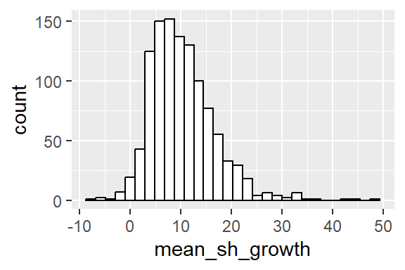

```r
ggplot(data_shoots,aes(mean_sh_growth))+geom_histogram(color="black",fill="white")
```

# Analyses

## With selfed progeny

```r
length(levels(data_selfed$id_parent))
```

```
## [1] 42
```

Selfed offpsring from 42 maternal families. id_parent is mother and father. Temp is temperature of th “grandmother” of the plant.

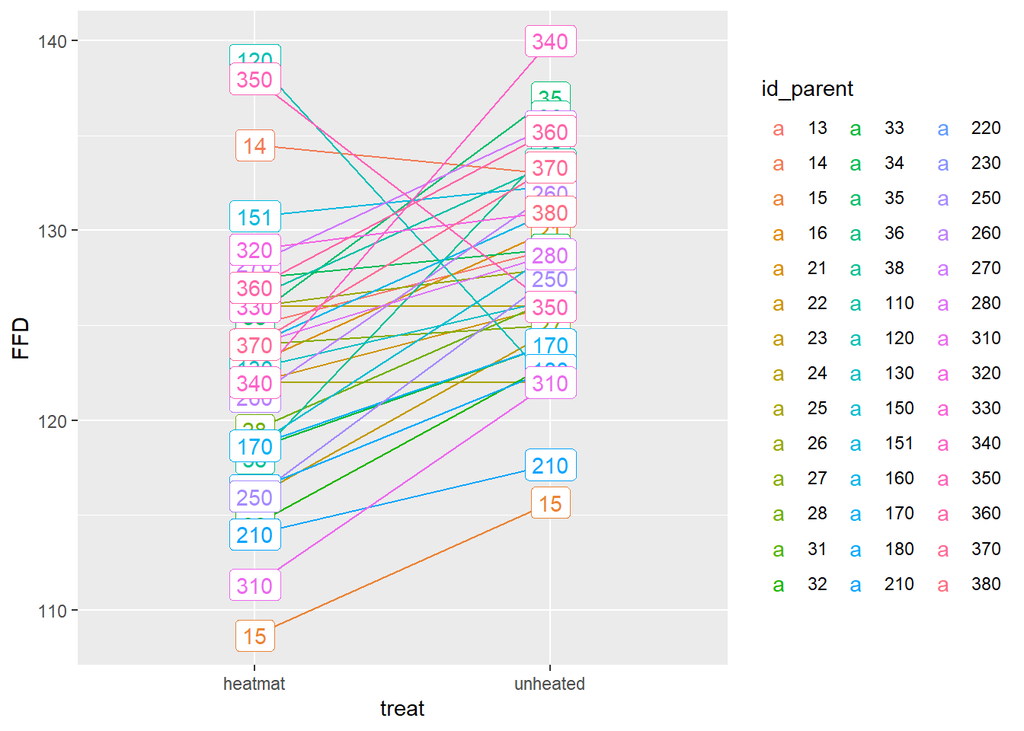

```r
data_selfed%>%group_by(id_parent,treat)%>%
  summarise(mean=mean(FFD),sd=sd(FFD))%>%
  ggplot(aes(x=treat,y=mean,group=id_parent,color=id_parent,label=id_parent))+
  geom_line()+geom_label()+ylab("FFD")
```

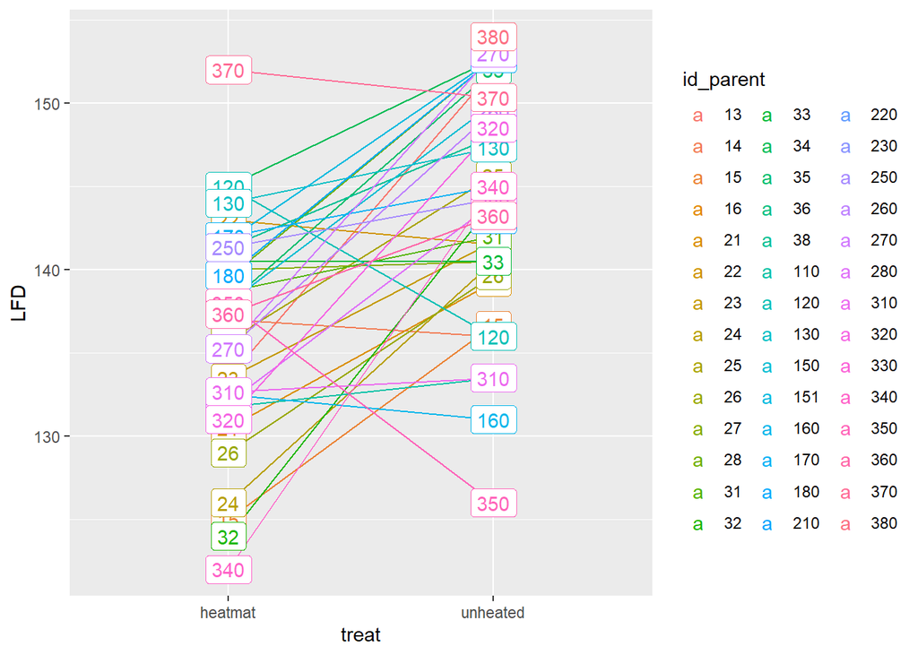

```r
data_selfed%>%group_by(id_parent,treat)%>%
  summarise(mean=mean(LFD),sd=sd(LFD))%>%
  ggplot(aes(x=treat,y=mean,group=id_parent,color=id_parent,label=id_parent))+
  geom_line()+geom_label()+ylab("LFD")
```

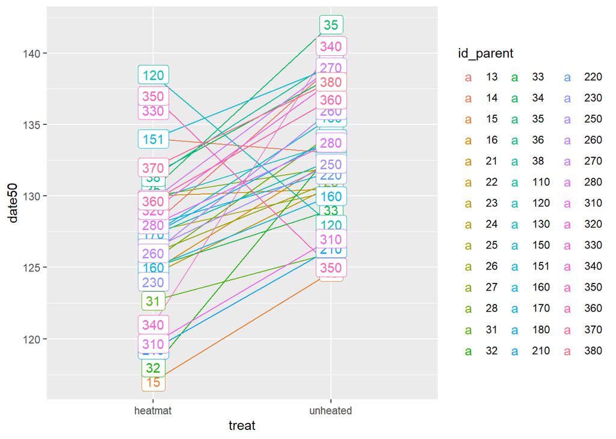

```r
data_selfed%>%group_by(id_parent,treat)%>%
  summarise(mean=mean(date50),sd=sd(date50))%>%
  ggplot(aes(x=treat,y=mean,group=id_parent,color=id_parent,label=id_parent))+
  geom_line()+geom_label()+ylab("date50")
```

Differences in RNs between the 42 maternal lines?

2-3 look quite different in the plots above.

```r
model_selfed_FFD_1<-lm(FFD~id_parent*treat,data_selfed)
model_selfed_LFD_1<-lm(LFD~id_parent*treat,data_selfed)
model_selfed_date50_1<-lm(date50~id_parent*treat,data_selfed)
Anova(model_selfed_FFD_1)
```

|  | Sum Sq | Df | F value | Pr(>F) |
| --- | --- | --- | --- | --- |
| id_parent | 5509.073 | 41 | 2.6264341 | 3.690506e-05 |
| treat | 1488.438 | 1 | 29.0939515 | 4.103180e-07 |
| id_parent:treat | 1238.709 | 35 | 0.6917882 | 8.933104e-01 |
| Residuals | 5525.250 | 108 | NA | NA |

```r
Anova(model_selfed_LFD_1)
```

|  | Sum Sq | Df | F value | Pr(>F) |
| --- | --- | --- | --- | --- |
| id_parent | 4670.502 | 41 | 2.023105 | 2.093785e-03 |
| treat | 2606.876 | 1 | 46.297668 | 6.071962e-10 |
| id_parent:treat | 1874.063 | 35 | 0.950944 | 5.534889e-01 |
| Residuals | 6024.833 | 107 | NA | NA |

```r
Anova(model_selfed_date50_1)
```

|  | Sum Sq | Df | F value | Pr(>F) |
| --- | --- | --- | --- | --- |
| id_parent | 3028.3279 | 41 | 2.0761876 | 1.456112e-03 |
| treat | 1599.1617 | 1 | 44.9510595 | 9.553282e-10 |
| id_parent:treat | 792.3657 | 35 | 0.6363634 | 9.363392e-01 |
| Residuals | 3842.1667 | 108 | NA | NA |

This suggests that there are no significant differences among individuals in the slope of the RNs. But there are differences in RN elevation.

Differences in RNs depend on origin temperature?

```r
model_selfed_FFD_2<-glmmTMB(FFD~temp*treat+(1|id_parent),data_selfed)
model_selfed_LFD_2<-glmmTMB(LFD~temp*treat+(1|id_parent),data_selfed)
model_selfed_date50_2<-glmmTMB(date50~temp*treat+(1|id_parent),data_selfed)
Anova(model_selfed_FFD_2)
```

|  | Chisq | Df | Pr(>Chisq) |
| --- | --- | --- | --- |
| temp | 0.7247990 | 1 | 3.945742e-01 |
| treat | 33.9902127 | 1 | 5.538999e-09 |
| temp:treat | 0.9372904 | 1 | 3.329756e-01 |

```r
Anova(model_selfed_LFD_2)
```

|  | Chisq | Df | Pr(>Chisq) |
| --- | --- | --- | --- |
| temp | 7.5825203 | 1 | 5.893698e-03 |
| treat | 49.1951397 | 1 | 2.317241e-12 |
| temp:treat | 0.8206826 | 1 | 3.649807e-01 |

```r
Anova(model_selfed_date50_2)
```

|  | Chisq | Df | Pr(>Chisq) |
| --- | --- | --- | --- |
| temp | 5.641495010 | 1 | 1.754024e-02 |
| treat | 51.016748947 | 1 | 9.158118e-13 |
| temp:treat | 0.002060784 | 1 | 9.637918e-01 |

For LFD and date 50, differences in elevation related to origin temperature. No differences in slope.

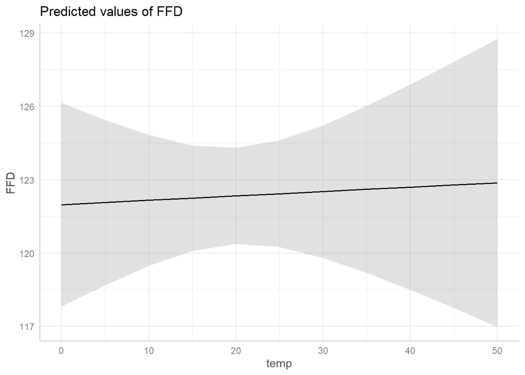

```r
plot(ggpredict(model_selfed_FFD_2,terms=c("temp")))
```

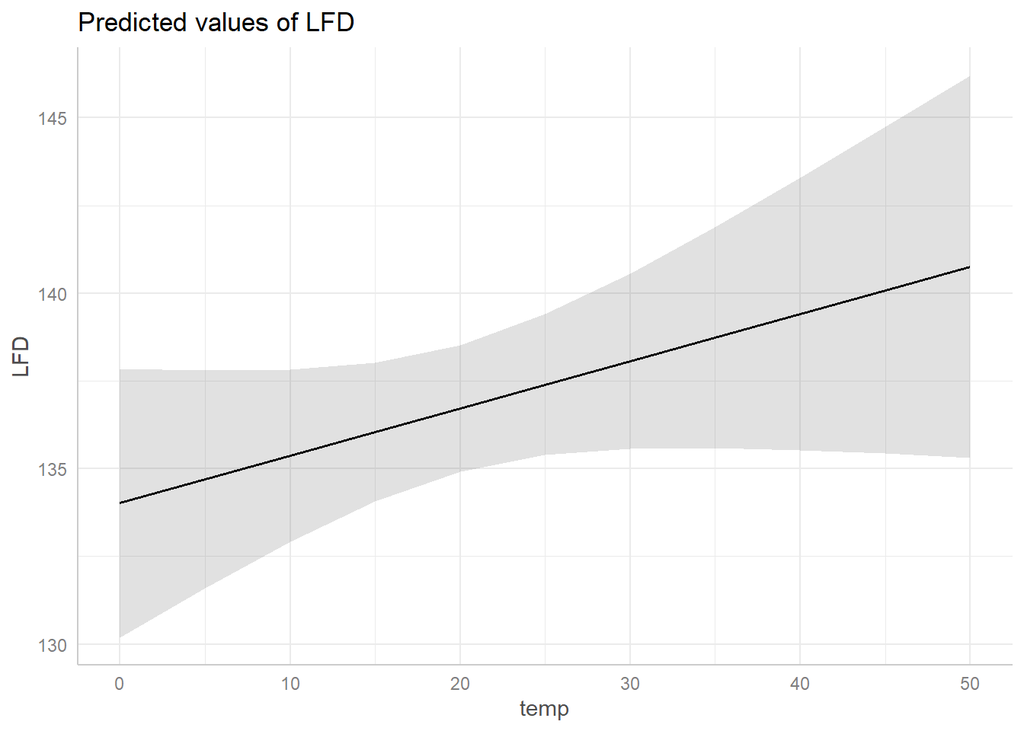

```r
plot(ggpredict(model_selfed_LFD_2,terms=c("temp")))
```

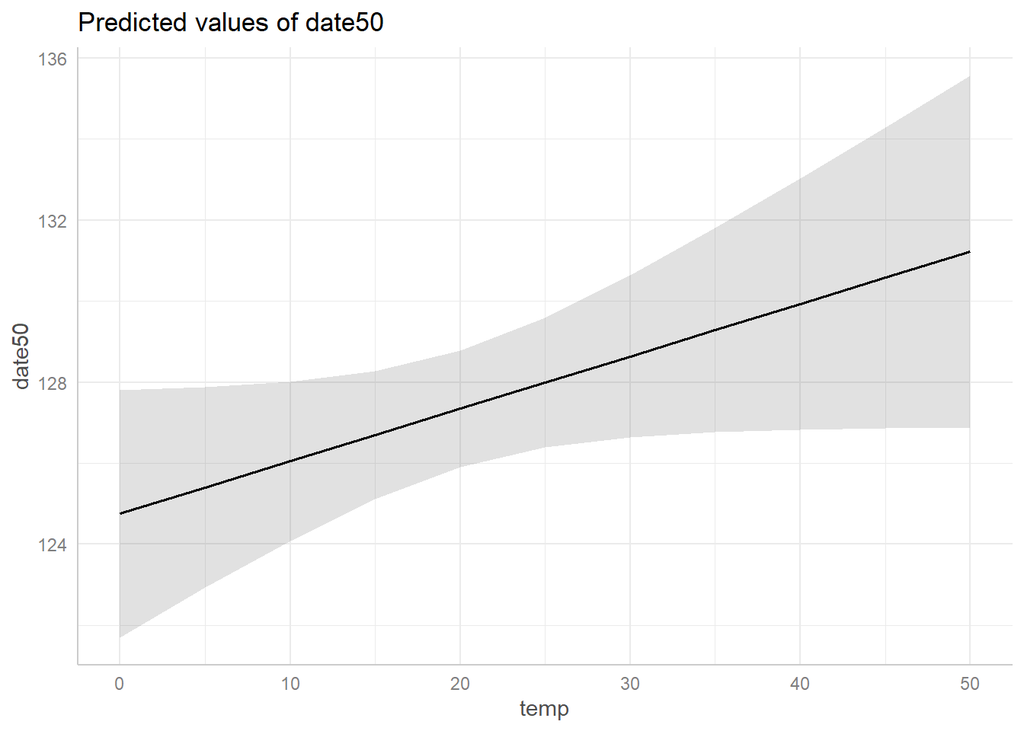

```r
plot(ggpredict(model_selfed_date50_2,terms=c("temp")))
```

## With progeny from crossings

### Flowering phenology

#### Temperature mother + father

Including mother, father and crossing as random factors.

```r
model_offpsring_FFD<-glmmTMB(FFD~(temp_mother+temp_father)*treat+
                               (1|mother)+(1|father)+(1|mother_father),data_exp)
model_offpsring_LFD<-glmmTMB(LFD~(temp_mother+temp_father)*treat+
                               (1|mother)+(1|father)+(1|mother_father),data_exp)
model_offpsring_date50<-glmmTMB(date50~(temp_mother+temp_father)*treat+
                               (1|mother)+(1|father)+(1|mother_father),data_exp)
model_offpsring_duration<-glmmTMB(duration~(temp_mother+temp_father)*treat+
                               (1|mother)+(1|father)+(1|mother_father),data_exp)
```

Save models as HTML table

```r
tab_model(model_offpsring_FFD,model_offpsring_LFD,model_offpsring_date50,
          model_offpsring_duration,
          transform=NULL,show.ci=F,show.se=T,show.stat=T,digits=3,
          dv.labels=c("FFD","LFD","date50","duration"),
          file="output/tables/Table_models_fl_phen.html",
          title="Models flowering phenology")
```

Models flowering phenology

|  | FFD |  |  |  | LFD |  |  |  | date50 |  |  |  | duration |  |  |  |
| --- | --- | --- | --- | --- | --- | --- | --- | --- | --- | --- | --- | --- | --- | --- | --- | --- |
| Predictors | Estimates | std. Error | Statistic | p | Estimates | std. Error | Statistic | p | Estimates | std. Error | Statistic | p | Estimates | std. Error | Statistic | p |
| (Intercept) | 119.805 | 2.176 | 55.065 | **<0.001** | 135.515 | 1.975 | 68.626 | **<0.001** | 123.564 | 1.821 | 67.853 | **<0.001** | 15.642 | 2.679 | 5.839 | **<0.001** |
| temp mother | -0.017 | 0.094 | -0.176 | 0.860 | 0.076 | 0.085 | 0.901 | 0.368 | 0.075 | 0.081 | 0.926 | 0.355 | 0.094 | 0.110 | 0.853 | 0.394 |
| temp father | 0.029 | 0.050 | 0.570 | 0.569 | 0.060 | 0.049 | 1.229 | 0.219 | 0.084 | 0.037 | 2.276 | **0.023** | 0.034 | 0.072 | 0.468 | 0.640 |
| treat [unheated] | 9.019 | 1.450 | 6.222 | **<0.001** | 10.026 | 1.838 | 5.454 | **<0.001** | 9.850 | 1.232 | 7.996 | **<0.001** | 1.144 | 2.205 | 0.519 | 0.604 |
| temp mother × treat [unheated] | 0.008 | 0.059 | 0.144 | 0.885 | 0.054 | 0.075 | 0.728 | 0.467 | 0.008 | 0.050 | 0.159 | 0.874 | 0.042 | 0.089 | 0.471 | 0.637 |
| temp father × treat [unheated] | 0.010 | 0.042 | 0.247 | 0.805 | -0.012 | 0.054 | -0.220 | 0.826 | -0.030 | 0.036 | -0.843 | 0.399 | -0.025 | 0.064 | -0.382 | 0.702 |
| Random Effects |  |  |  |  |  |  |  |  |  |  |  |  |  |  |  |  |
| σ<sup>2</sup> | 47.78 |  |  |  | 77.31 |  |  |  | 34.70 |  |  |  | 110.53 |  |  |  |
| τ<sub>00</sub> | 10.76 <sub>mother</sub> |  |  |  | 6.43 <sub>mother</sub> |  |  |  | 8.56 <sub>mother</sub> |  |  |  | 10.88 <sub>mother</sub> |  |  |  |
|  | 3.58 <sub>father</sub> |  |  |  | 1.79 <sub>father</sub> |  |  |  | 1.55 <sub>father</sub> |  |  |  | 6.28 <sub>father</sub> |  |  |  |
|  | 2.33 <sub>mother_father</sub> |  |  |  | 1.65 <sub>mother_father</sub> |  |  |  | 0.63 <sub>mother_father</sub> |  |  |  | 6.90 <sub>mother_father</sub> |  |  |  |
| ICC | 0.26 |  |  |  | 0.11 |  |  |  | 0.24 |  |  |  | 0.18 |  |  |  |
| N | 25 <sub>mother</sub> |  |  |  | 25 <sub>mother</sub> |  |  |  | 25 <sub>mother</sub> |  |  |  | 25 <sub>mother</sub> |  |  |  |
|  | 24 <sub>father</sub> |  |  |  | 24 <sub>father</sub> |  |  |  | 24 <sub>father</sub> |  |  |  | 24 <sub>father</sub> |  |  |  |
|  | 98 <sub>mother_father</sub> |  |  |  | 98 <sub>mother_father</sub> |  |  |  | 98 <sub>mother_father</sub> |  |  |  | 98 <sub>mother_father</sub> |  |  |  |
| Observations | 844 |  |  |  | 845 |  |  |  | 845 |  |  |  | 844 |  |  |  |
| Marginal R<sup>2</sup> / Conditional R<sup>2</sup> | 0.257 / 0.450 |  |  |  | 0.258 / 0.342 |  |  |  | 0.337 / 0.494 |  |  |  | 0.011 / 0.188 |  |  |  |

Only effects of treatment are significant for FFD and LFD, also temp_father for date50. No significant effect of treatment on duration.

Plot predictions of significant effects

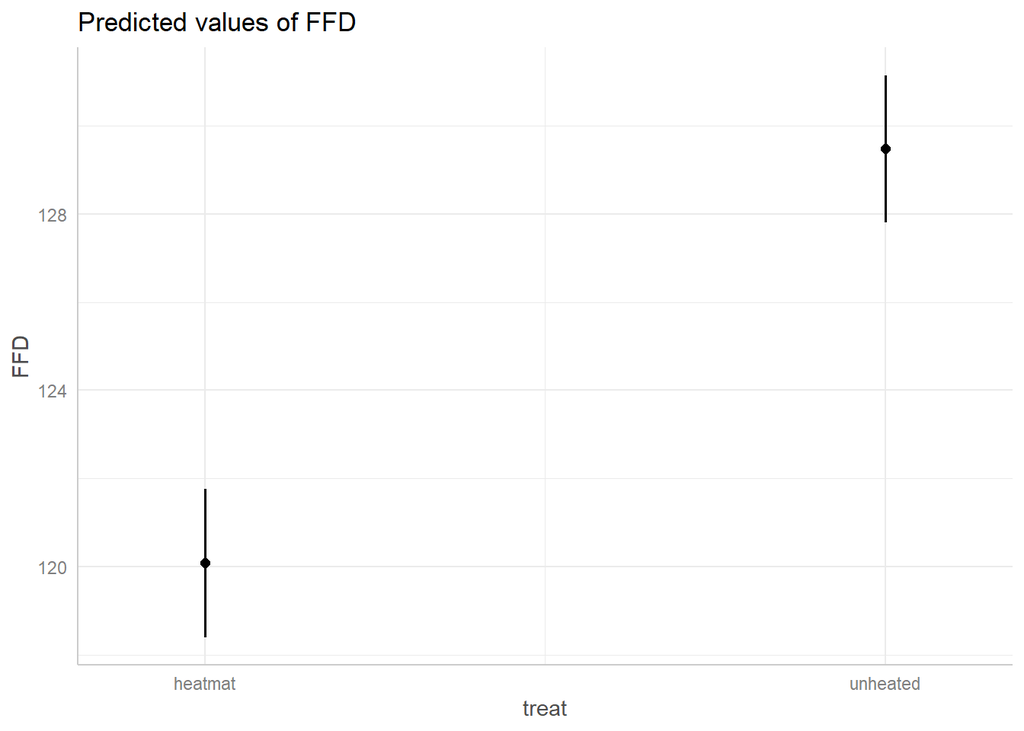

```r
plot(ggpredict(model_offpsring_FFD,terms=c("treat")))
```

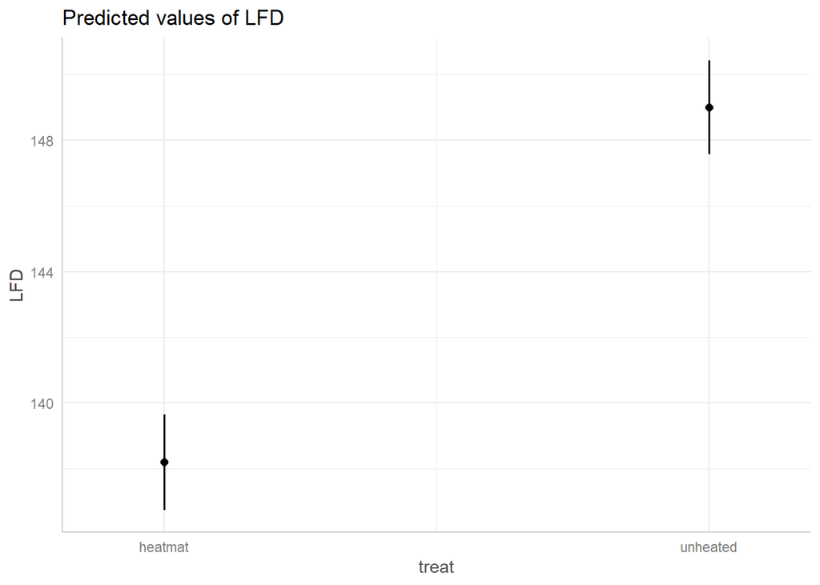

```r
plot(ggpredict(model_offpsring_LFD,terms=c("treat")))
```

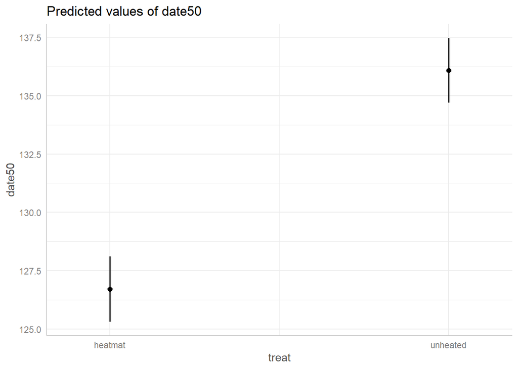

```r
plot(ggpredict(model_offpsring_date50,terms=c("treat")))
```

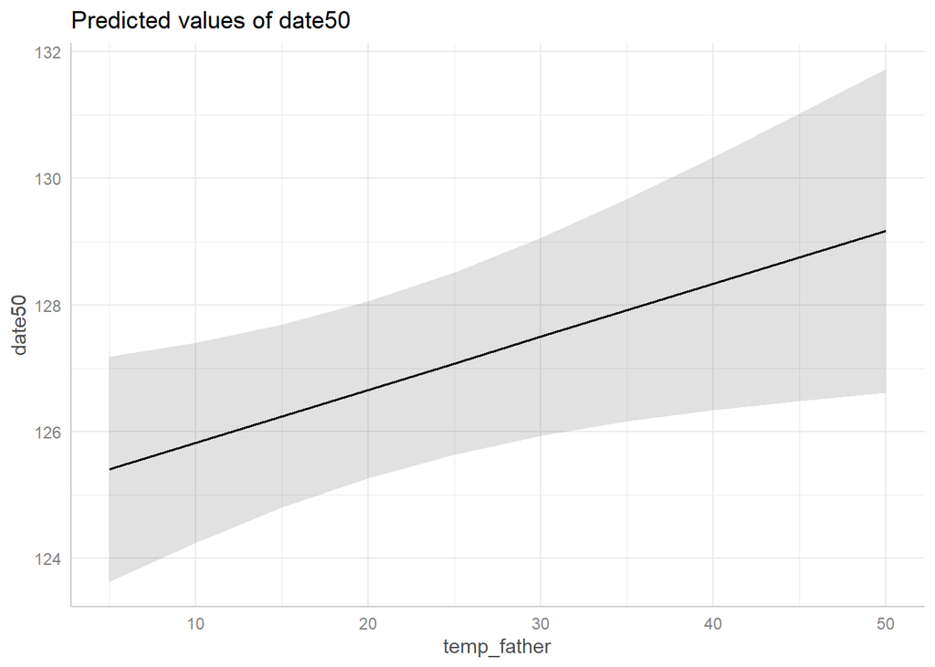

```r
plot(ggpredict(model_offpsring_date50,terms=c("temp_father")))
```

Plot predictions of interactions (NS)

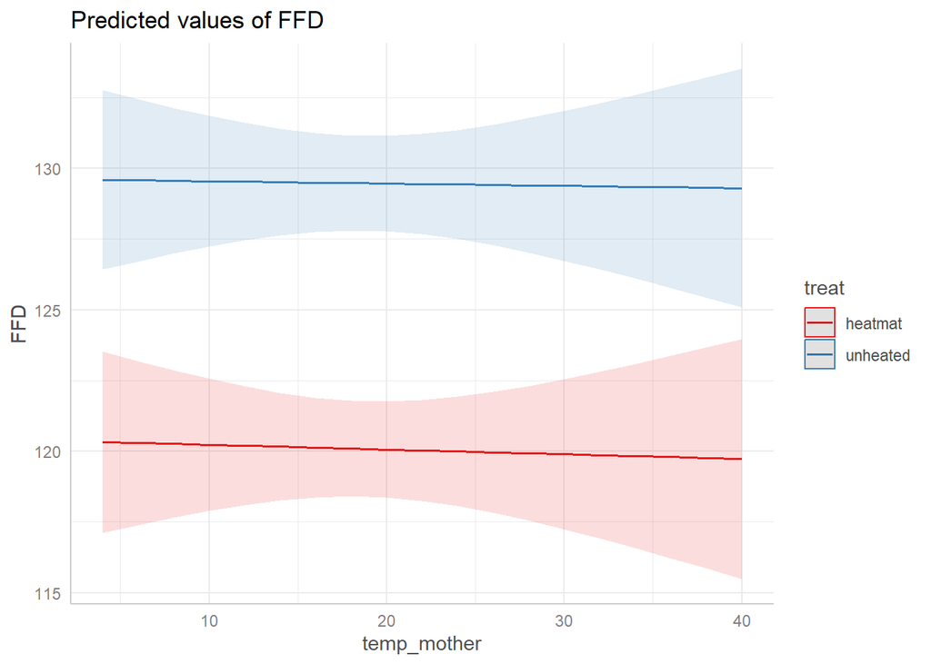

```r
plot(ggpredict(model_offpsring_FFD,terms=c("temp_mother","treat")))
```

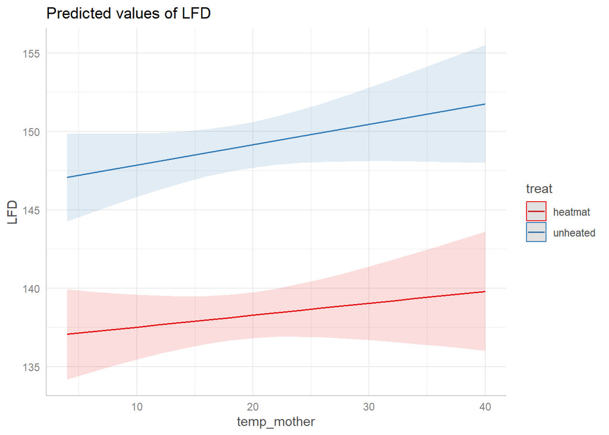

```r
plot(ggpredict(model_offpsring_LFD,terms=c("temp_mother","treat")))
```

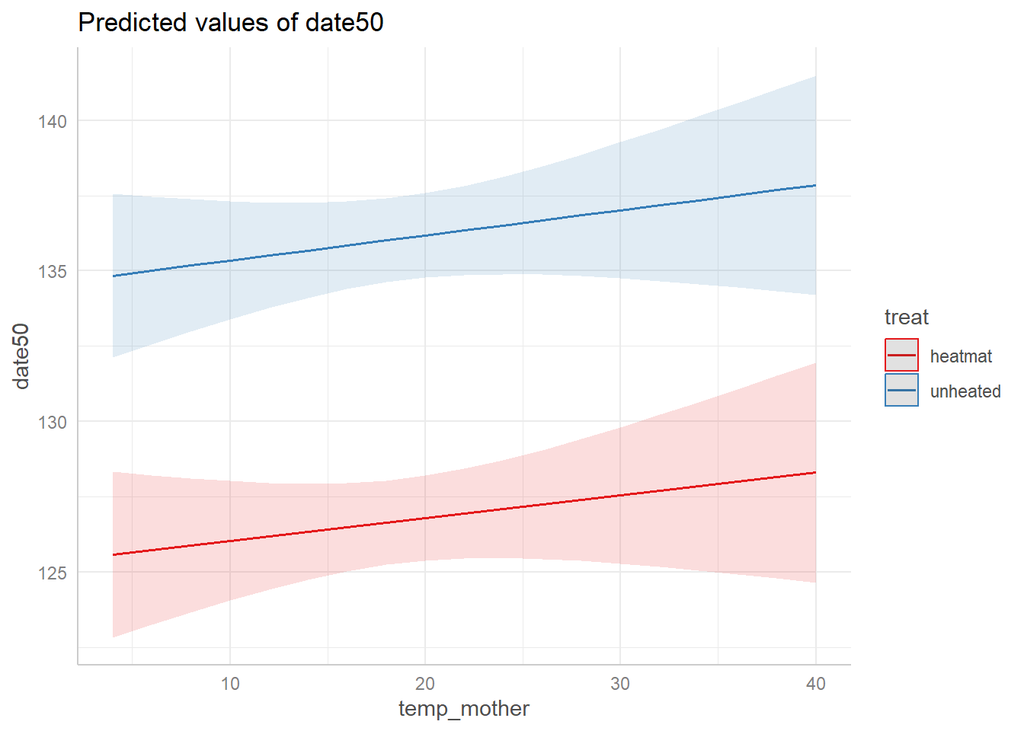

```r
plot(ggpredict(model_offpsring_date50,terms=c("temp_mother","treat")))
```

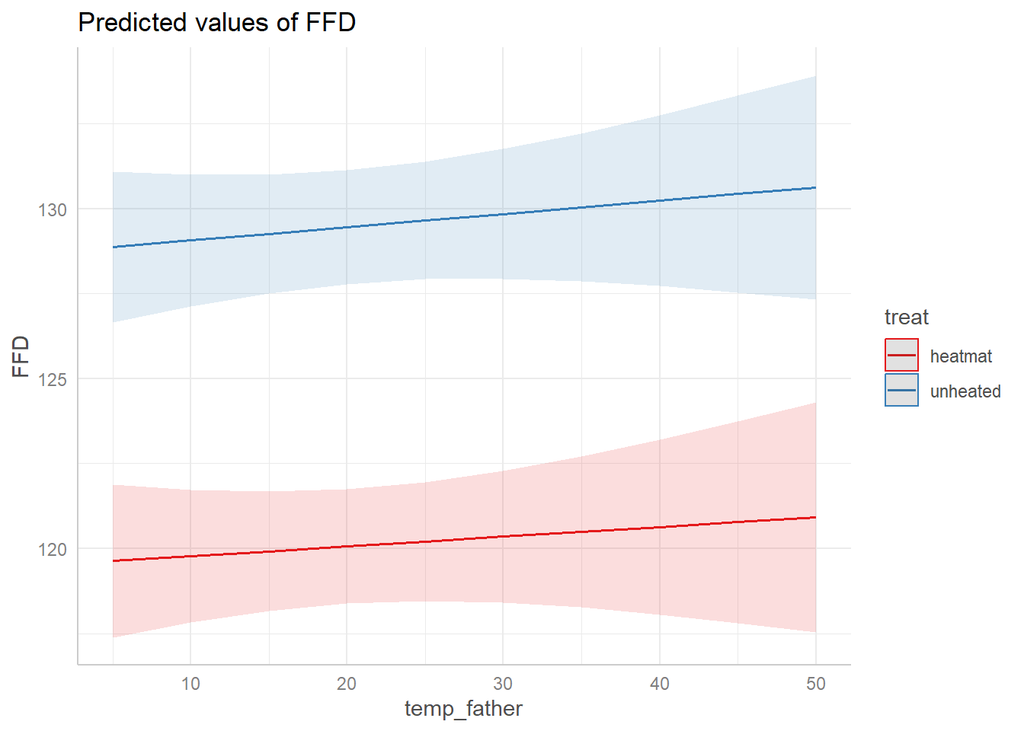

```r
plot(ggpredict(model_offpsring_FFD,terms=c("temp_father","treat")))
```

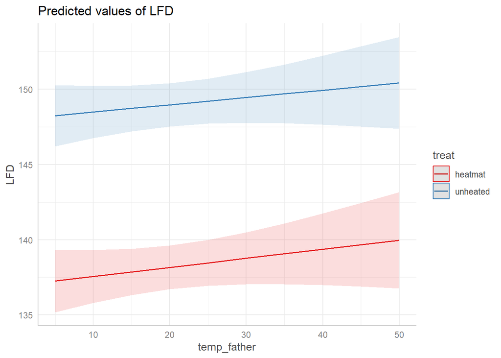

```r
plot(ggpredict(model_offpsring_LFD,terms=c("temp_father","treat")))
```

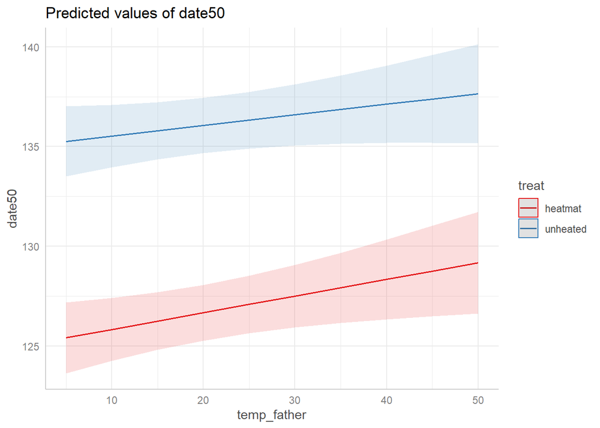

```r
plot(ggpredict(model_offpsring_date50,terms=c("temp_father","treat")))
```

#### Mean temperature mother & father

```r
data_exp$mean_temp_parents<-with(data_exp,(temp_mother+temp_father)/2)
```

```r
model_offpsring_FFD_mean<-glmmTMB(FFD~mean_temp_parents*treat+
                               (1|mother)+(1|father)+(1|mother_father),data_exp)
model_offpsring_LFD_mean<-glmmTMB(LFD~mean_temp_parents*treat+
                               (1|mother)+(1|father)+(1|mother_father),data_exp)
model_offpsring_date50_mean<-glmmTMB(date50~mean_temp_parents*treat+
                               (1|mother)+(1|father)+(1|mother_father),data_exp)
model_offpsring_duration_mean<-glmmTMB(duration~mean_temp_parents*treat+
                               (1|mother)+(1|father)+(1|mother_father),data_exp)
```

Save models as HTML table

```r
tab_model(model_offpsring_FFD_mean,model_offpsring_LFD_mean,model_offpsring_date50_mean,
          model_offpsring_duration_mean,
          transform=NULL,show.ci=F,show.se=T,show.stat=T,digits=3,
          dv.labels=c("FFD","LFD","date50","duration"),
          file="output/tables/Table_models_fl_phen_mean.html",
          title="Models flowering phenology with mean temperature of parents")
```

Models flowering phenology with mean temperature of parents

|  | FFD |  |  |  | LFD |  |  |  | date50 |  |  |  | duration |  |  |  |
| --- | --- | --- | --- | --- | --- | --- | --- | --- | --- | --- | --- | --- | --- | --- | --- | --- |
| Predictors | Estimates | std. Error | Statistic | p | Estimates | std. Error | Statistic | p | Estimates | std. Error | Statistic | p | Estimates | std. Error | Statistic | p |
| (Intercept) | 119.320 | 1.894 | 63.009 | **<0.001** | 135.839 | 1.787 | 76.017 | **<0.001** | 123.623 | 1.448 | 85.355 | **<0.001** | 16.162 | 2.557 | 6.322 | **<0.001** |
| mean temp parents | 0.039 | 0.086 | 0.445 | 0.656 | 0.119 | 0.083 | 1.437 | 0.151 | 0.156 | 0.065 | 2.417 | **0.016** | 0.098 | 0.119 | 0.824 | 0.410 |
| treat [unheated] | 9.006 | 1.399 | 6.437 | **<0.001** | 10.373 | 1.774 | 5.847 | **<0.001** | 10.046 | 1.189 | 8.448 | **<0.001** | 1.496 | 2.129 | 0.703 | 0.482 |
| mean temp parents × treat [unheated] | 0.020 | 0.066 | 0.298 | 0.766 | 0.022 | 0.084 | 0.259 | 0.796 | -0.034 | 0.057 | -0.600 | 0.549 | -0.004 | 0.101 | -0.035 | 0.972 |
| Random Effects |  |  |  |  |  |  |  |  |  |  |  |  |  |  |  |  |
| σ<sup>2</sup> | 47.78 |  |  |  | 77.34 |  |  |  | 34.72 |  |  |  | 110.55 |  |  |  |
| τ<sub>00</sub> | 10.89 <sub>mother</sub> |  |  |  | 6.44 <sub>mother</sub> |  |  |  | 8.56 <sub>mother</sub> |  |  |  | 11.13 <sub>mother</sub> |  |  |  |
|  | 3.59 <sub>father</sub> |  |  |  | 1.87 <sub>father</sub> |  |  |  | 1.55 <sub>father</sub> |  |  |  | 6.52 <sub>father</sub> |  |  |  |
|  | 2.32 <sub>mother_father</sub> |  |  |  | 1.67 <sub>mother_father</sub> |  |  |  | 0.63 <sub>mother_father</sub> |  |  |  | 6.91 <sub>mother_father</sub> |  |  |  |
| ICC | 0.26 |  |  |  | 0.11 |  |  |  | 0.24 |  |  |  | 0.18 |  |  |  |
| N | 25 <sub>mother</sub> |  |  |  | 25 <sub>mother</sub> |  |  |  | 25 <sub>mother</sub> |  |  |  | 25 <sub>mother</sub> |  |  |  |
|  | 24 <sub>father</sub> |  |  |  | 24 <sub>father</sub> |  |  |  | 24 <sub>father</sub> |  |  |  | 24 <sub>father</sub> |  |  |  |
|  | 98 <sub>mother_father</sub> |  |  |  | 98 <sub>mother_father</sub> |  |  |  | 98 <sub>mother_father</sub> |  |  |  | 98 <sub>mother_father</sub> |  |  |  |
| Observations | 844 |  |  |  | 845 |  |  |  | 845 |  |  |  | 844 |  |  |  |
| Marginal R<sup>2</sup> / Conditional R<sup>2</sup> | 0.256 / 0.450 |  |  |  | 0.256 / 0.341 |  |  |  | 0.336 / 0.493 |  |  |  | 0.007 / 0.188 |  |  |  |

Only effects of treatment are significant for FFD and LFD, also mean_temp_parents for date50.

No significant effect of treatment on duration.

Plot predictions of significant effects

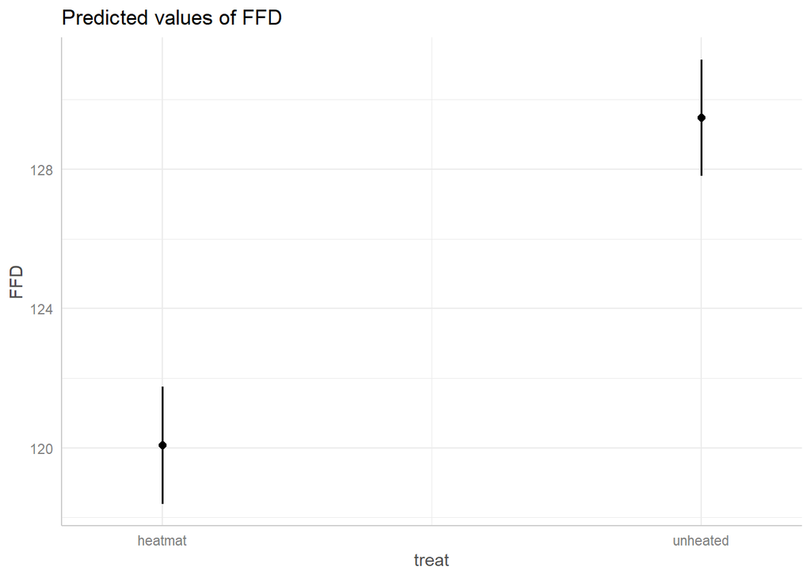

```r
plot(ggpredict(model_offpsring_FFD_mean,terms=c("treat")))
```

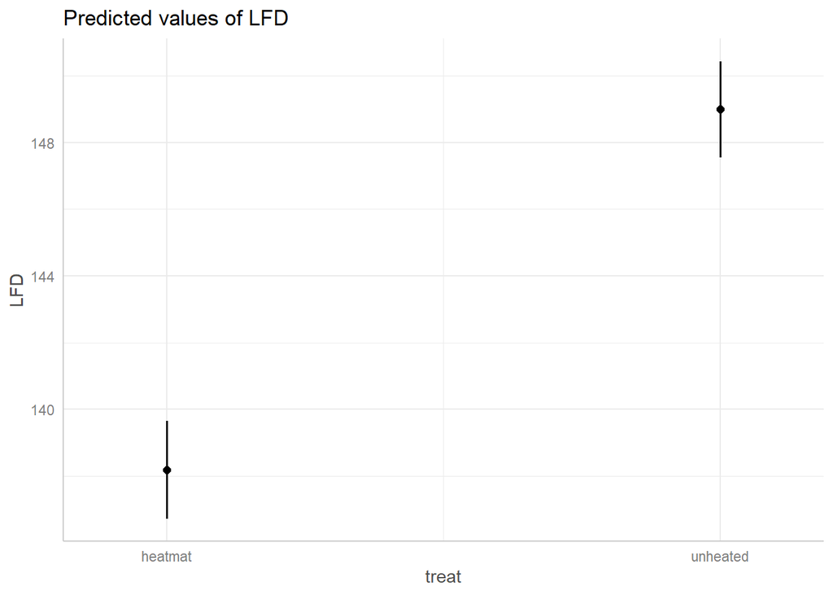

```r
plot(ggpredict(model_offpsring_LFD_mean,terms=c("treat")))
```

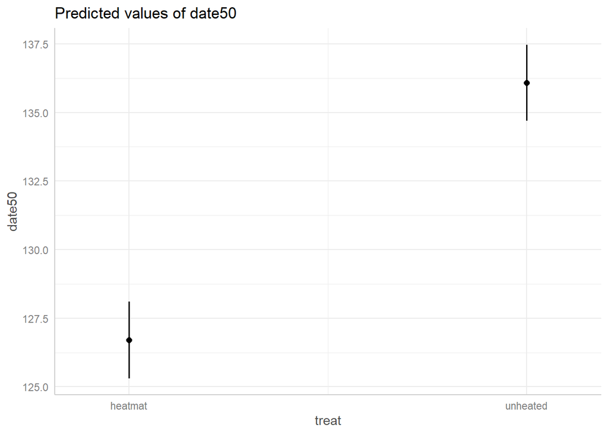

```r
plot(ggpredict(model_offpsring_date50_mean,terms=c("treat")))
```

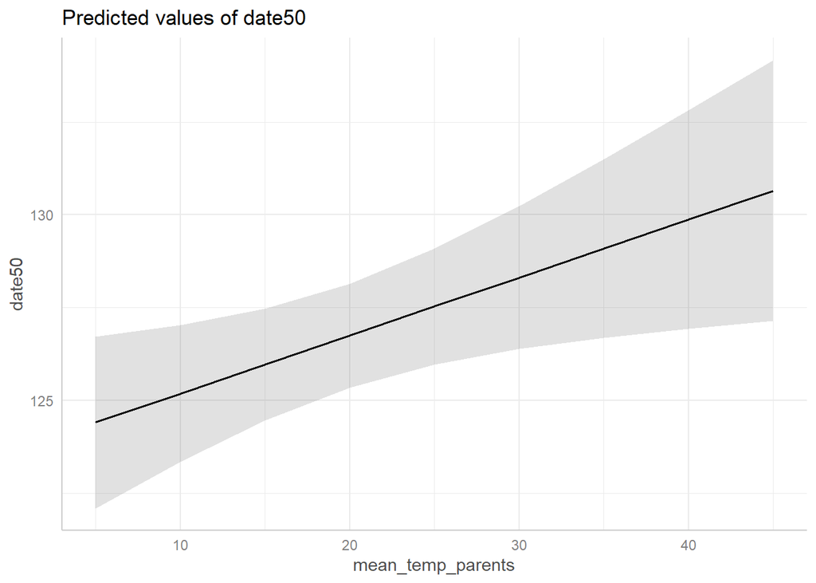

```r
plot(ggpredict(model_offpsring_date50_mean,terms=c("mean_temp_parents")))
```

Plot predictions of interactions (NS)

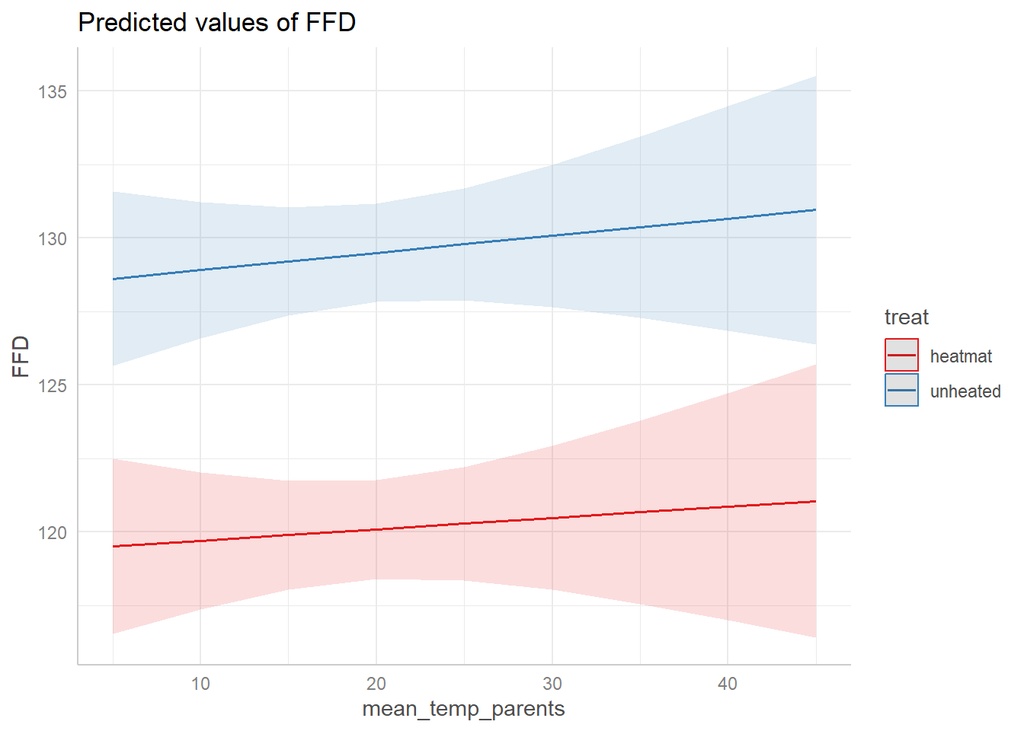

```r
plot(ggpredict(model_offpsring_FFD_mean,terms=c("mean_temp_parents","treat")))
```

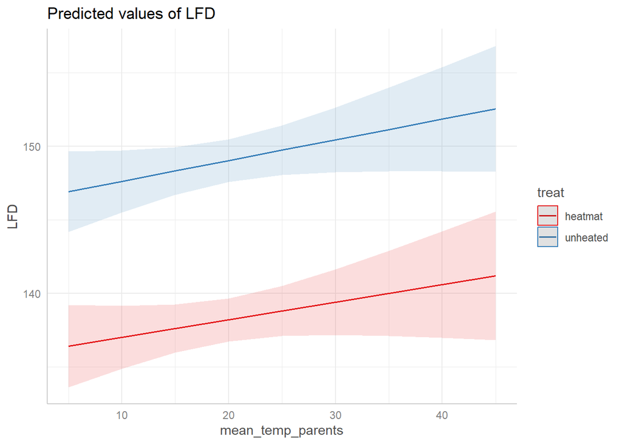

```r
plot(ggpredict(model_offpsring_LFD_mean,terms=c("mean_temp_parents","treat")))
```

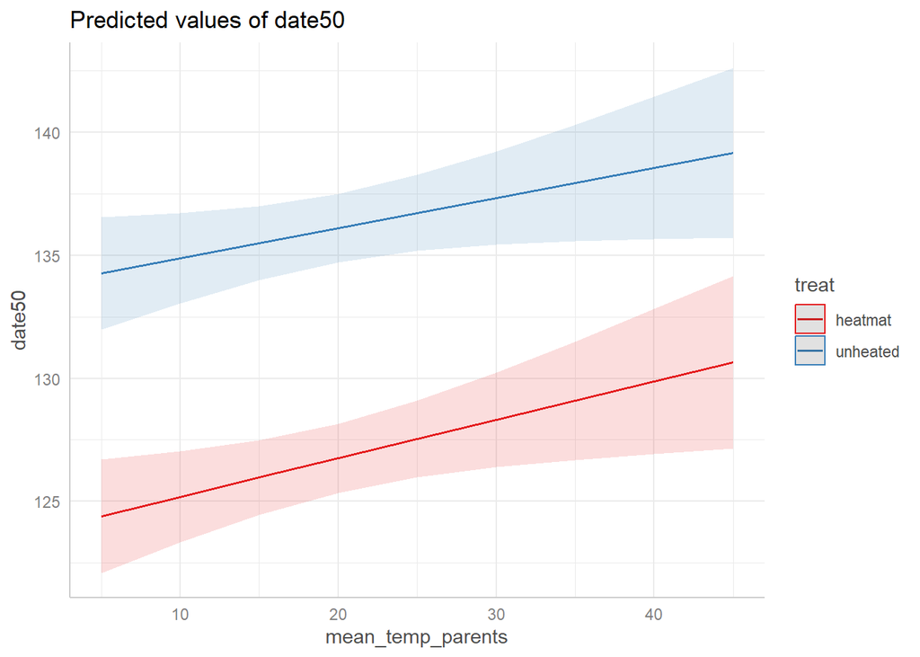

```r
plot(ggpredict(model_offpsring_date50_mean,terms=c("mean_temp_parents","treat")))
```